# Conditioning monitoring

This exercise demonstrates the use of machine learning to identify a normal operational threshold to prevent failures.

There are two approaches:

- comparing the Mahalanobis distance from each data point to the normal group centroid
- comparing the mean absolute error from the error loss from each data point to the predicted data point using a Neural Network Autoencoder

#### Dataset

https://ti.arc.nasa.gov/tech/dash/groups/pcoe/prognostic-data-repository/#turbofan

#### Source code:

https://towardsdatascience.com/machine-learning-for-anomaly-detection-and-condition-monitoring-d4614e7de770

### Load libraries

```python
import numpy as np
import pandas as pd
import os

import matplotlib.pyplot as plt
%matplotlib inline

from sklearn import preprocessing
from sklearn.decomposition import PCA

import seaborn as sns
sns.set(color_codes=True)

from sklearn.covariance import MinCovDet , EmpiricalCovariance

from numpy.random import seed
import tensorflow
from keras.layers import Input, Dropout
from keras.layers.core import Dense
from keras.models import Model, Sequential, load_model
from keras import regularizers
from keras.models import model_from_json
```

### Load data

```python
# Load only the second dataset
merged_dataset_name = 'merged_dataset_BearingTest_2.csv'
data_dir = 'IMS/2nd_test'
merged_data = pd.DataFrame()

if os.path.exists(merged_dataset_name):
    merged_data = pd.read_csv(merged_dataset_name)
    merged_data.index = merged_data[merged_data.columns[0]].values
    merged_data.index = pd.to_datetime(merged_data.index)
    merged_data = merged_data.sort_index()
    merged_data = merged_data[merged_data.columns[1:]]
else:
    for ix, filename in enumerate(os.listdir(data_dir)):
        dataset=pd.read_csv(os.path.join(data_dir, filename), sep='\t',
                            header=None)
        dataset_mean_abs = np.array(dataset.abs().mean())
        # 1st_test files have 8 columns instead of 4
        if data_dir == 'IMS/1st_test':
            dataset_mean_abs = \
            dataset_mean_abs.reshape((2,4), order="F").mean(axis=0)
        dataset_mean_abs = pd.DataFrame(dataset_mean_abs.reshape(1,4))
        dataset_mean_abs.index = [filename]
        merged_data = merged_data.append(dataset_mean_abs)
    merged_data.columns = ['Bearing 1','Bearing 2','Bearing 3','Bearing 4']
    # Arrange index to std format
    merged_data.index = pd.to_datetime(merged_data.index,
                                   format='%Y.%m.%d.%H.%M.%S')
    merged_data = merged_data.sort_index()
    merged_data.to_csv(merged_dataset_name)
merged_data.head()
```

|  | Bearing 1 | Bearing 2 | Bearing 3 | Bearing 4 |
| --- | --- | --- | --- | --- |
| 2004-02-12 10:32:39 | 0.058332 | 0.071832 | 0.083244 | 0.043065 |
| 2004-02-12 10:42:39 | 0.058997 | 0.074008 | 0.084439 | 0.044540 |
| 2004-02-12 10:52:39 | 0.060239 | 0.074223 | 0.083922 | 0.044442 |
| 2004-02-12 11:02:39 | 0.061453 | 0.073843 | 0.084462 | 0.045081 |
| 2004-02-12 11:12:39 | 0.061361 | 0.075606 | 0.082837 | 0.045118 |

```python
merged_data.shape
```

```
(984, 4)
```

There are 984 files in the data set. Each file contains thousands of measurements of four bearings at a particular timestamp, but we only considered the average of those measurements as a single row (1x4) for each file

#### Separate training from testing data from a given time range

```python
# Define train and test sets
dataset_train = merged_data['2004-02-12 11:02:39':'2004-02-13 23:52:39']
dataset_test = merged_data['2004-02-13 23:52:39':]
```

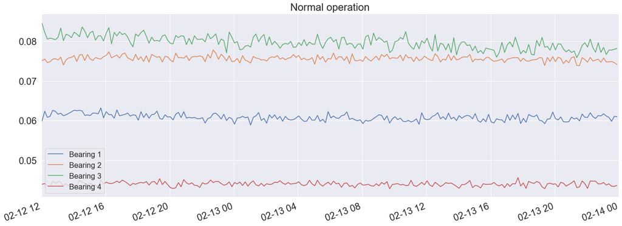

```python
# Plot the training dataset as normal operation
ax = dataset_train.plot(figsize = (22,8), fontsize = 20,
                  rot=20)
plt.title("Normal operation", fontsize=22)
plt.legend(loc=3, prop={'size': 16})
plt.xlim(['2004-02-12 12:00:00','2004-02-14 00:00:00'])
plt.show()
```

#### Normalize data assuming all data points are inliers

```python
# Normalize data
scaler = preprocessing.MinMaxScaler()

X_train = pd.DataFrame(scaler.fit_transform(dataset_train),
                              columns=dataset_train.columns,
                              index=dataset_train.index)
# Random shuffle training data
X_train.sample(frac=1)

X_test = pd.DataFrame(scaler.transform(dataset_test),
                             columns=dataset_test.columns,
                             index=dataset_test.index)
```

#### Reduce dimensionality to two variables

```python
# Use PCA to reduce to 2 components
pca = PCA(n_components=2, svd_solver= 'full')
X_train_PCA = pca.fit_transform(X_train)
X_train_PCA = pd.DataFrame(X_train_PCA)
X_train_PCA.index = X_train.index

X_test_PCA = pca.transform(X_test)
X_test_PCA = pd.DataFrame(X_test_PCA)
X_test_PCA.index = X_test.index
```

#### Visualize train (blue) and test data (red) distributions

```
<function matplotlib.pyplot.show(*args, **kw)>
```

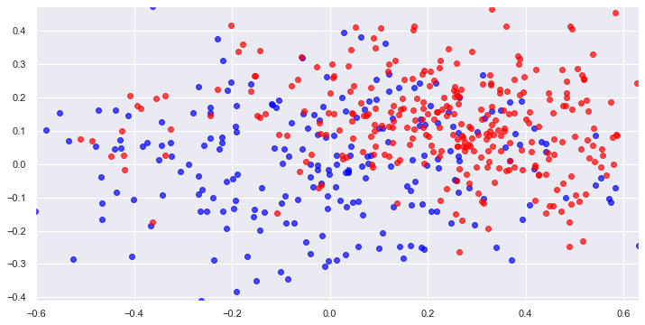

```python
# Plot train and test data sets
plt.figure(2, figsize=(12, 6))
x_min, x_max = np.min(X_train_PCA[0]), np.max(X_train_PCA[0])
y_min, y_max = np.min(X_train_PCA[1]), np.max(X_train_PCA[1])
plt.xlim(x_min, x_max)
plt.ylim(y_min, y_max)
plt.scatter(X_train_PCA[0], X_train_PCA[1], c="blue", alpha=0.7)
plt.scatter(X_test_PCA[0], X_test_PCA[1], c="red", alpha=0.7)
plt.show
```

### Define helper functions

```python
# Covariance using numpy cov
def cov_matrix(data, verbose=False):
    covariance_matrix = np.cov(data, rowvar=False)
    if is_pos_def(covariance_matrix):
        inv_covariance_matrix = np.linalg.inv(covariance_matrix)
        if is_pos_def(inv_covariance_matrix):
            return covariance_matrix, inv_covariance_matrix
        else:
            print("Error: Inverse of Covariance Matrix is not positive definite!")
    else:
        print("Error: Covariance Matrix is not positive definite!")
```

```python
# Covariance using MinCovDet
random_state = 7
def cov_matrix_MinCovDet(data):
    cov_matrix = MinCovDet(random_state=random_state).fit(data)
    cov = cov_matrix.covariance_
    cov_inv = np.linalg.inv(cov)
    return cov, cov_inv
```

```python
# Covariance using EmpiricalCovariance
def cov_matrix_EmpiricalCovariance(data):
    cov_matrix = EmpiricalCovariance().fit(data)
    cov = cov_matrix.covariance_
    cov_inv = np.linalg.inv(cov)
    return cov, cov_inv
```

```python
# Mahalanobis distance
def MahalanobisDist(inv_cov_matrix, mean_distr, data, verbose=False):
    inv_covariance_matrix = inv_cov_matrix
    vars_mean = mean_distr
    diff = data - vars_mean
    md = []
    for i in range(len(diff)):
        md.append(np.sqrt(diff[i].dot(inv_covariance_matrix).dot(diff[i])))
    return md
```

```python
# Detect outliers using a threshold value of 3 times the std dev
def MD_detectOutliers(dist, extreme=False, verbose=False):
    k = 3. if extreme else 2.
    threshold = np.mean(dist) * k
    outliers = []
    for i in range(len(dist)):
        if dist[i] >= threshold:
            outliers.append(i)  # index of the outlier
    return np.array(outliers)
```

```python
# Calculate threshold value with 3 times the std dev
def MD_threshold(dist, extreme=False, verbose=False):
    k = 3. if extreme else 2.
    threshold = np.mean(dist) * k
    return threshold
```

```python
# Check if positive definitive
def is_pos_def(A):
    if np.allclose(A, A.T):
        try:
            np.linalg.cholesky(A)
            return True
        except np.linalg.LinAlgError:
            return False
    else:
        return False
```

### Calculate normality using Mahalanobis distances

#### Use feature reduced model

```python
# Define train/test sets for model
data_train = np.array(X_train_PCA.values)
data_test = np.array(X_test_PCA.values)
```

#### Calculate Covariance matriz and its inverse using one of three methods

```python
# Calculate covariance matrix and its inverse
#cov_matrix, inv_cov_matrix  = cov_matrix(data_train)
#cov_matrix, inv_cov_matrix  = cov_matrix_MinCovDet(data_train)
cov_matrix, inv_cov_matrix  = cov_matrix_EmpiricalCovariance(data_train)
```

#### Calculate the normal group centroid

```python
# Calculate mean values for training set - Centroid
mean_distr = data_train.mean(axis=0)
```

#### Calculate Mahalanobis distance from train/test datasets to the normal centroid, and get the normal threshold

```python
# Calculate distances from centroid to train and test sets
dist_test = MahalanobisDist(inv_cov_matrix, mean_distr, data_test, verbose=False)
dist_train = MahalanobisDist(inv_cov_matrix, mean_distr, data_train, verbose=False)
threshold = MD_threshold(dist_train, extreme = True)
print("Threshold ", threshold)
```

```
Threshold  3.820979668260425
```

#### Plot the square train distance

```
(0.0, 15)
```

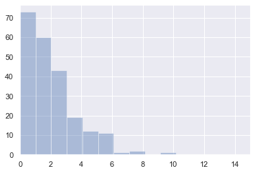

```python
# The square of the Mahalanobis distance should follow a Chi-2 distr
plt.figure()
sns.distplot(np.square(dist_train),
             bins = 10,
             kde= False);
plt.xlim([0.0,15])
```

#### Plot the actual train distance

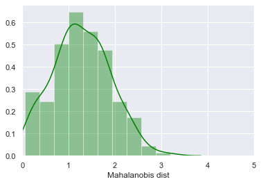

```python
# Plot the Mahalanobis distribution
plt.figure()
sns.distplot(dist_train,
             bins = 10,
             kde= True,
            color = 'green');
plt.xlim([0.0,5])
plt.xlabel('Mahalanobis dist')
```

Threshold = 3.8209 seems to capture most of training data variability

#### Create a pandas dataframe to manage results

```python
# Save train/test distances
# and a logical flag for data that exceed threshold
anomaly_train = pd.DataFrame()
anomaly_train['Mob dist']= dist_train
anomaly_train['Thresh'] = threshold
# If Mob dist above threshold: Flag as anomaly
anomaly_train['Anomaly'] = anomaly_train['Mob dist'] > anomaly_train['Thresh']
anomaly_train.index = X_train_PCA.index
anomaly = pd.DataFrame()
anomaly['Mob dist']= dist_test
anomaly['Thresh'] = threshold
# If Mob dist above threshold: Flag as anomaly
anomaly['Anomaly'] = anomaly['Mob dist'] > anomaly['Thresh']
anomaly.index = X_test_PCA.index
anomaly.head()
```

|  | Mob dist | Thresh | Anomaly |
| --- | --- | --- | --- |
| 2004-02-13 23:52:39 | 1.036169 | 3.82098 | False |
| 2004-02-14 00:02:39 | 1.152847 | 3.82098 | False |
| 2004-02-14 00:12:39 | 1.514940 | 3.82098 | False |
| 2004-02-14 00:22:39 | 1.857769 | 3.82098 | False |
| 2004-02-14 00:32:39 | 0.699639 | 3.82098 | False |

#### Join train and test distance dataframes

```python
# Merge two sets into a single csv
anomaly_alldata = pd.concat([anomaly_train, anomaly])
anomaly_alldata.to_csv('Anomaly_distance.csv')
```

```python
np.sum(anomaly["Anomaly"].values)
```

```
411
```

```python
anomaly_alldata.shape
```

```
(982, 3)
```

#### Plot all distances compared to the calculated threshold

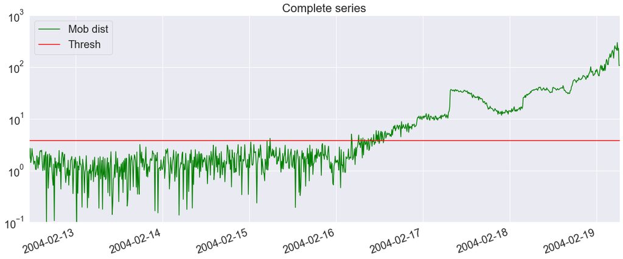

```python
# Plot complete series
ax = anomaly_alldata.plot(logy=True, color = ['green','red'],
                          ylim = [1e-1,1e3],
                          figsize = (20,8), fontsize = 20,
                          rot=20)
plt.title("Complete series", fontsize=22)
plt.legend(loc=0, prop={'size': 20})
plt.show()
```

### Define normality using Autoencoders loss

#### Define NN architecture

```python
# Define NN model with Keras
seed(10)
tensorflow.random.set_seed(10)
act_func = 'elu'

# Input layer:
model=Sequential()
# First hidden layer, connected to input vector X.
model.add(Dense(10,activation=act_func,
                kernel_initializer='glorot_uniform',
                kernel_regularizer=regularizers.l2(0.0),
                input_shape=(X_train.shape[1],)
               )
         )

model.add(Dense(2,activation=act_func,
                kernel_initializer='glorot_uniform'))

model.add(Dense(10,activation=act_func,
                kernel_initializer='glorot_uniform'))

model.add(Dense(X_train.shape[1],
                kernel_initializer='glorot_uniform'))

model.compile(loss='mse',optimizer='adam')

# Train model for 100 epochs, batch size of 10:
NUM_EPOCHS=100
BATCH_SIZE=10
```

#### Train the model

```python
# Train the model
history=model.fit(np.array(X_train),np.array(X_train),
                  batch_size=BATCH_SIZE,
                  epochs=NUM_EPOCHS,
                  validation_split=0.05,
                  verbose = 1)
```

```
Train on 210 samples, validate on 12 samples
```

#### Plot training and validation loss for epochs

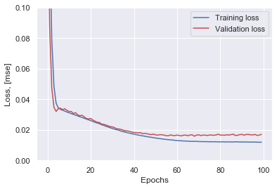

```python
# Plot training and val losses
plt.plot(history.history['loss'],
         'b',
         label='Training loss')
plt.plot(history.history['val_loss'],
         'r',
         label='Validation loss')
plt.legend(loc='upper right')
plt.xlabel('Epochs')
plt.ylabel('Loss, [mse]')
plt.ylim([0,.1])
plt.show()
```

#### Predict values for train data and calculate error loss against actual train data

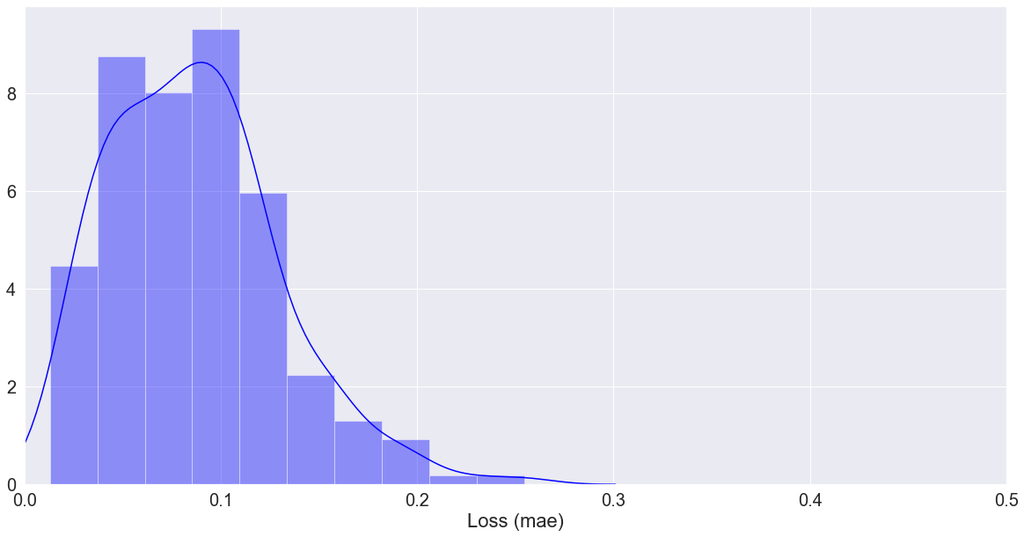

```python
# Propose a threshold based on the training loss
X_pred = model.predict(np.array(X_train))
X_pred = pd.DataFrame(X_pred,
                      columns=X_train.columns)
X_pred.index = X_train.index

scored = pd.DataFrame(index=X_train.index)
scored['Loss_mae'] = np.mean(np.abs(X_pred-X_train), axis = 1)
plt.figure(figsize=(20,10))

ax = sns.distplot(scored['Loss_mae'],
             bins = 10, hist=True,
             kde= True,
            color = 'blue');

ax.tick_params(axis='both', which='major', labelsize=20)
ax.tick_params(axis='both', which='minor', labelsize=20)

plt.xlim([0.0,0.5])
plt.xlabel('Loss (mae)', fontsize=22)
plt.show()
```

A threshold = 0.3 seems to capture most of the observations

```python
print("Min loss value",np.min(scored.values))
print("Max loss value",np.max(scored.values))
print("Mean loss value",np.mean(scored.values))
```

```
Min loss value 0.012971952984488055
Max loss value 0.25441073747839127
Mean loss value 0.08643592099082441
```

Though 0.255 should be enough

```python
threshold = .255
```

#### Plot cumulative loss

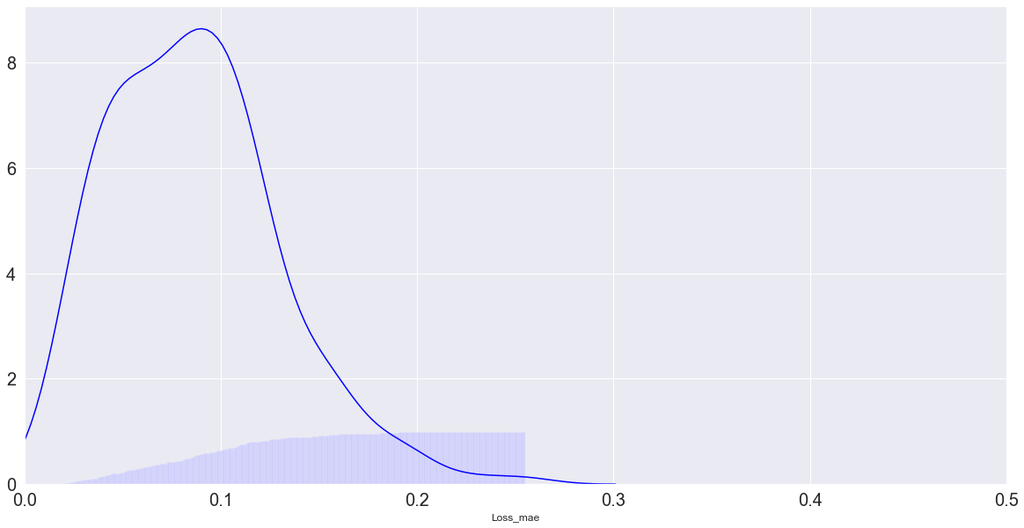

```python
# Plot a cumulative distribution to validate the threshold
kwargs = {'cumulative': True}
plt.figure(figsize=(20,10))
ax = sns.distplot(scored['Loss_mae'],
             bins = 1000, hist=True,
             kde= True,
            color = 'blue',
            hist_kws=kwargs);
ax.tick_params(axis='both', which='major', labelsize=20)
ax.tick_params(axis='both', which='minor', labelsize=20)
plt.xlim([0.0,.5])
plt.show()
```

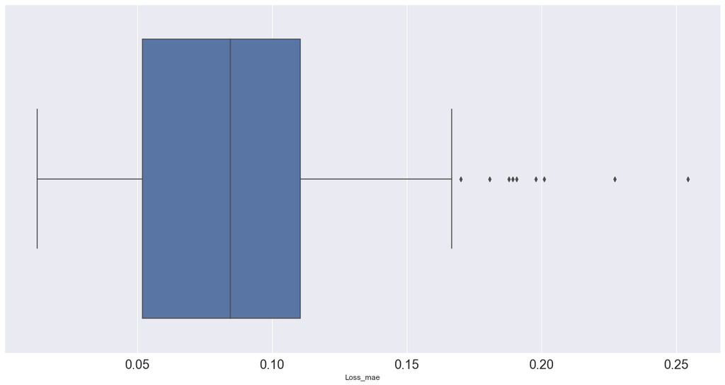

```python
# Plot a boxplot to confirm the distribution
plt.figure(figsize=(20,10))
ax = sns.boxplot(scored['Loss_mae'], whis=.99)
ax.tick_params(axis='both', which='major', labelsize=20)
ax.tick_params(axis='both', which='minor', labelsize=20)
```

#### Predict values for test data and calculate anomalies against threshold

```python
# Use the model to predict values for test data set
X_pred = model.predict(np.array(X_test))
X_pred = pd.DataFrame(X_pred,
                      columns=X_test.columns)
X_pred.index = X_test.index

scored = pd.DataFrame(index=X_test.index)
scored['Loss_mae'] = np.mean(np.abs(X_pred-X_test), axis = 1)
scored['Threshold'] = threshold
scored['Anomaly'] = scored['Loss_mae'] > scored['Threshold']
scored.head()
```

|  | Loss_mae | Threshold | Anomaly |
| --- | --- | --- | --- |
| 2004-02-13 23:52:39 | 0.131275 | 0.255 | False |
| 2004-02-14 00:02:39 | 0.117459 | 0.255 | False |
| 2004-02-14 00:12:39 | 0.034940 | 0.255 | False |
| 2004-02-14 00:22:39 | 0.143666 | 0.255 | False |
| 2004-02-14 00:32:39 | 0.070426 | 0.255 | False |

#### Predict values for train data, calculate anomalies against threshold, and join results with test data

```python
# Use the model to predict values for train data set and concatenate with test data
X_pred_train = model.predict(np.array(X_train))
X_pred_train = pd.DataFrame(X_pred_train,
                      columns=X_train.columns)
X_pred_train.index = X_train.index

scored_train = pd.DataFrame(index=X_train.index)
scored_train['Loss_mae'] = np.mean(np.abs(X_pred_train-X_train), axis = 1)
scored_train['Threshold'] = threshold
scored_train['Anomaly'] = scored_train['Loss_mae'] > scored_train['Threshold']
scored = pd.concat([scored_train, scored])
```

#### Plot loss compared to the calculated threshold

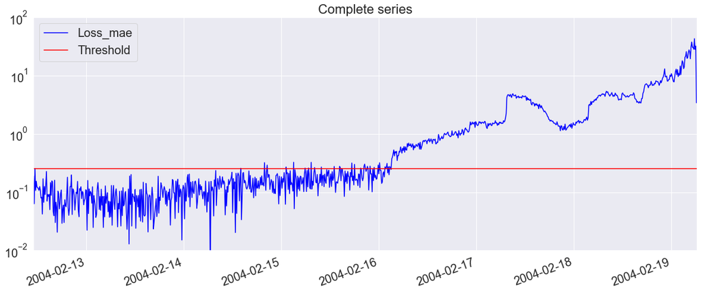

```python
# Plot series
ax = scored.plot(logy=True, color = ['blue','red'],
                 ylim = [1e-2,1e2], figsize = (20,8),
                 fontsize = 20, rot=20)
plt.title("Complete series", fontsize=22)
plt.legend(loc=0, prop={'size': 20})
plt.show()
```

```python
np.sum(scored['Anomaly'])
```

```
482
```

```python
scored.shape
```

```
(982, 3)
```

### Conclusions

With both strategis, we defined a valid threshold to anticipate two days to the failure event

For furthre work, we could use different metric to measure distances, different covariance matrix, and different NN architecture.